# Plastic Pollution and its Economic Drivers

**Research Question**

How are demographic, economic, and geographic characteristics of countries associated with differences in plastic collected during cleanup audits?

**GDP vs Plastic Pollution**

The Big Picture

GDP is the one of the most popular measures of a country’s economic health. In this plot, we can see how that surface level measurement relates to the plastic audited by region through the world.

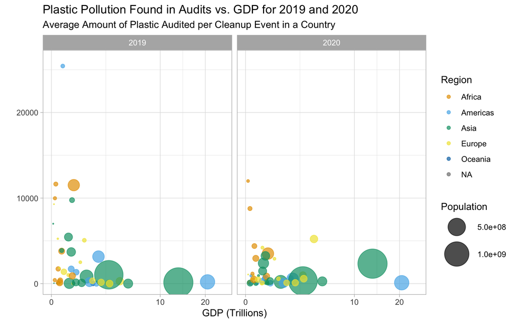

**GDP vs Plastic Types**

Plastic Types by GDP Categories

The plastic type audited in a country may be affected by the country’s economic health. This plot differentiates this health by the GDP per Capita metric. Once again often used to denote economic health.

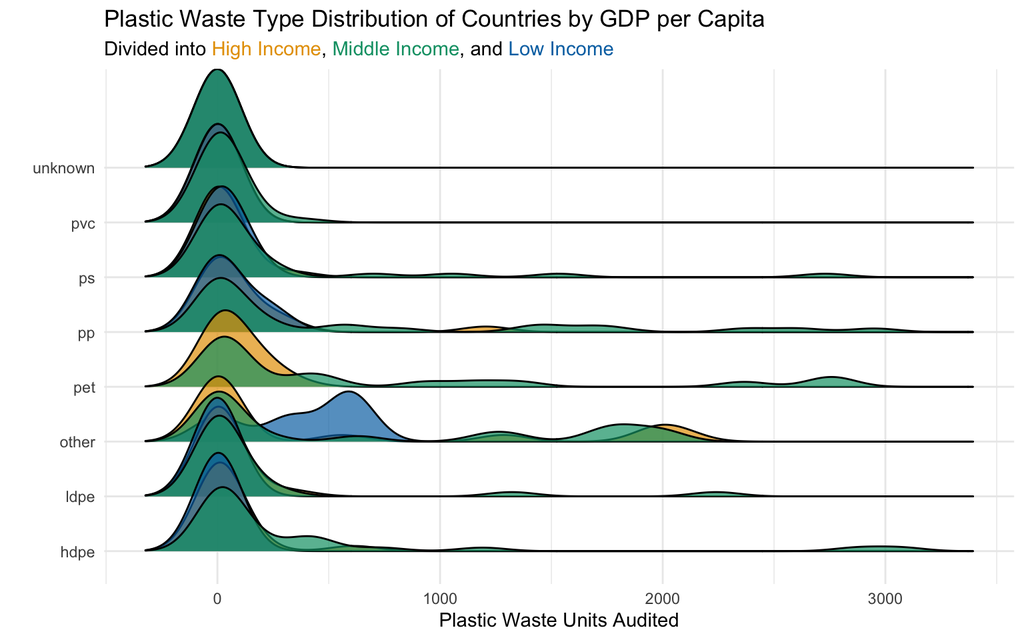

**Waste Producers**

Economic Drivers = Plastic Waste Generators???

The presence of large corporations withing a country may also affect the plastic being produced. This table explores which companies produce the most plastic waste that was audited within a country.

[interactive chart not shown]

**Model Description**

Our Model

This mixed effects model examines how population, population density, GDP, year, and geographic region are associated with the amount of plastic collected in cleanup audits. The response variable is the logged total number of plastic items collected for each country/year.

Population, population density, and GDP are also log transformed so the model is more stable rather than the raw units. Region and year are included as fixed effects, while country is included as a random effect to account for repeated observations from the same country across years.

Only log population is statistically significant in the mixed model, suggesting that countries with larger populations tend to have higher audited plastic totals, while population density, GDP, year, and region do not show significant associations after accounting for country level variation.

**Exploring the Data**

Environmental Metrics for 5 Most Populated Countries

Summary of Plastic Compared to Environmental Indicators for the 5 Most Populated Countries

Country-Year Summary of Plastics and Environmental Data

| Country | Year | Total Plastic Items Collected | Average Plastic Items Collected | Ecological Footprint per Capita | Biocapacity per Capita | HDI | Population |
| --- | --- | --- | --- | --- | --- | --- | --- |
| China | 2019 | 6,918 | 11 | 3.42 | 0.72 | NA | 1,453,799,936 |
| China | 2020 | 2,332 | 11 | 3.45 | 0.72 | NA | 1,456,930,048 |
| India | 2019 | 4,132 | 20 | 1.08 | 0.34 | 0.64 | 1,383,110,016 |
| India | 2020 | 16,973 | 49 | 0.98 | 0.33 | 0.64 | 1,396,390,016 |
| Indonesia | 2019 | 26,618 | 42 | 1.68 | 1.24 | 0.72 | 269,583,008 |
| Indonesia | 2020 | 10,156 | 35 | 1.58 | 1.23 | 0.71 | 271,857,984 |
| Nigeria | 2020 | 63,253 | 189 | 0.89 | 0.45 | 0.54 | 208,327,008 |
| United States Of America | 2019 | 8,628 | 15 | 7.86 | 3.78 | 0.93 | 334,320,000 |
| United States Of America | 2020 | 13,991 | 37 | 7.23 | 3.82 | 0.92 | 335,942,016 |

**Type III ANOVA for Final Mixed Model**

Satterthwaite's method

| Predictor | Sum Sq | Mean Sq | NumDF | DenDF | F value | Pr(>F) |
| --- | --- | --- | --- | --- | --- | --- |
| Log Population | 19.880 | 19.880 | 1.000 | 45.595 | 5.162 | 0.028 |
| Log Population Density | 3.371 | 3.371 | 1.000 | 49.054 | 0.875 | 0.354 |
| Log GDP (billions) | 5.503 | 5.503 | 1.000 | 45.780 | 1.429 | 0.238 |
| Year | 1.617 | 1.617 | 1.000 | 45.222 | 0.420 | 0.520 |
| Region | 72.355 | 4.522 | 16.000 | 37.798 | 1.174 | 0.331 |

Why Nigeria?

Nigeria ranks among the highest contributors to plastic waste in our data set when summarized over all years. It is a very populated country and by the year 2050 it is projected to be the world’s third most populated country, only behind India and China. This made it a compelling country for more exploration and understanding other factors that contribute to the high levels of plastic pollution. By focusing on Nigeria, we aim to uncover how economic conditions and population infrastructure may affect the country’s plastic waste output. It is important to note that the kg per person per year metric shown in the map was calculated as follows: the total plastic waste collected over the years 2007-2017 and was then divided by the population of each state, then divided by 11 to express it as an annual per-capita figure.

Select metric to display:

[interactive chart not shown]